# How to Analyze Yearly Expenses in Colab

**Karen Y. Wang**

As a personal finance nut, I’ve made it a habit to analyze my expenses at the end of every year. At first, I started doing this because I wanted to identify areas where I could cut down on my spending. But, the most beneficial part of this exercise came from identifying areas I *enjoyed* spending money on—things like gifts, vacations, and nice meals with family and friends. This tutorial will show you how to use Python to analyze your yearly expenses. Hopefully, it will also help you gain a better understanding of your relationship to your spending habits.

## About Colab

Google Colaboratory, or Colab for short, is a free service that allows you to write and execute Python code in the browser. Code snippets and text elements are organized into Colab notebooks, which can be read as documents and shared with others.

# Before you begin

First, you'll need to login to your bank account and download your yearly transactions in CSV format. Next, you’ll need to upload the CSV file to Google Drive. For this tutorial we will be using my spending data from 2019.

# Setup

First, let's read the data in from the CSV file. To do this we will be using `pandas`, a Python data analysis library. Let's import the library and rename it to `pd` for short.

```python
import pandas as pd
```

Next, let's load the CSV file from Drive.

```python
from google.colab import drive
drive.mount('/content/drive')
```

Next, let's read the CSV file contents into a `pandas` table called `transactions`.

```python
transactions = pd.read_csv('/content/drive/My Drive/finance/2020-06-13_transaction_download.csv')
```

Now let's inspect the table contents. This can be done by calling `transactions.head()`, which returns the first five rows.

```python
transactions.head()
```

|  | Transaction Date | Posted Date | Card No. | Description | Category | Debit | Credit |
| --- | --- | --- | --- | --- | --- | --- | --- |
| 0 | 2019-12-28 | 2019-12-30 | 4704 | UINPIBOTSUKUSU | Other Services | 94.62 | NaN |
| 1 | 2019-12-26 | 2019-12-28 | 4704 | CHEESE | Merchandise | 13.71 | NaN |
| 2 | 2019-12-27 | 2019-12-28 | 4704 | SQ*BASEHAKUBA | Dining | 8.23 | NaN |
| 3 | 2019-12-25 | 2019-12-27 | 4704 | RAKUTENPAY EMBLEMHOSTELNI | Lodging | 106.29 | NaN |
| 4 | 2019-12-26 | 2019-12-27 | 4704 | Zappos.com | Merchandise | NaN | 119.03 |

Each row contains details about a particular transaction. `Description` specifies the merchant name and `Category` specifies the spending category. Each row also has a value in either `Debit` or `Credit`, which specifies whether that transaction was an expense or a refund. In the example above, I spent $\$13.71$ on cheese and got a refund of $\$119.03$ from Zappos.

You might be wondering what the `NaN` values refer to. `NaN` stands for "Not a Number," and appears in the place of an undefined numeric value. However, for our purposes, you can just ignore them.

# Breakdown by category

Now, I want to know which categories I spent the most money on. But first, what are all of the categories? We can list the unique values for the `Category` column to find out.

```python
transactions.Category.unique()
```

```
array(['Other Services', 'Merchandise', 'Dining', 'Lodging',
       'Other Travel', 'Phone/Cable', 'Gas/Automotive', 'Other',
       'Airfare', 'Payment/Credit', 'Health Care', 'Entertainment',
       'Professional Services', 'Insurance', 'Internet'], dtype=object)
```

Most of the categories make sense, except for one called `Payment/Credit`. It turns out this category is used to label credit card payments. We don't want to include these transactions in our calculations, so let's remove all rows categorized as `Payment/Credit`.

```python
transactions = transactions[transactions.Category != 'Payment/Credit']
```

Now let's determine the total amount spent for each category. We'll group transactions by category, compute the sum of each group, and store the results in a new table called `sum`.

```python
sum = transactions.groupby(['Category']).sum()
```

Let’s examine the `sum` table.

```python
sum.head()
```

| Category | Card No. | Debit | Credit |
| --- | --- | --- | --- |
| Airfare | 51744 | 3571.36 | 257.38 |
| Dining | 1735776 | 6586.22 | 0.00 |
| Entertainment | 174048 | 1641.27 | 0.00 |
| Gas/Automotive | 28224 | 346.06 | 0.00 |
| Health Care | 211680 | 2878.26 | 75.88 |

Recall that a transaction labeled `Debit` is an expense, and `Credit` is a refund. Therefore, in the `sum` table above, each row's `Debit` column contains the total amount spent in that category, and `Credit` contains the total amount refunded to that category.

To determine the final amount spent, we need to subtract credits from debits.

Let’s do some calculations! We’ll add a new column named `Total` to our table, and store the calculation results there.

```python
sum["Total"] = sum["Debit"] - sum["Credit"]
```

Now let's store our total spending for each category in a new table called `totals`, and take a look at the final result.

```python
totals = sum[["Total"]]
totals
```

| Category | Total |
| --- | --- |
| Airfare | 3313.98 |
| Dining | 6586.22 |
| Entertainment | 1641.27 |
| Gas/Automotive | 346.06 |
| Health Care | 2802.38 |
| Insurance | 23.21 |
| Internet | 31.14 |
| Lodging | 2960.50 |
| Merchandise | 7693.58 |
| Other | 2678.00 |
| Other Services | 810.07 |
| Other Travel | 1944.12 |
| Phone/Cable | 630.28 |
| Professional Services | 118.00 |

Let's visualize our results for easier interpretation. First, we'll sort the table on the `Total` column in descending order.

Next, we create a bar plot from the sorted table. The `rot` field specifies the angle at which to display the x-axis labels, and `figsize` specifies the figure size.

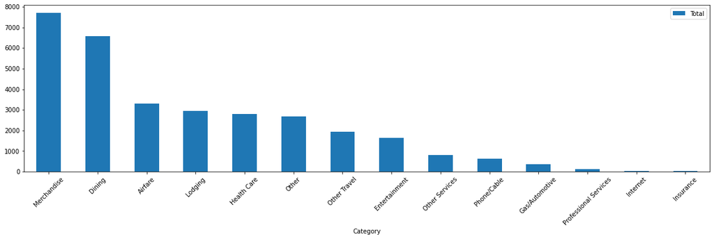

```python
totals = totals.sort_values(by=["Total"], ascending=False)
ax = totals.plot.bar(rot=45, figsize=(20,5))
```

It looks like dining was one of the categories I spent the most money on in 2019. This makes sense because I lived in New York City at the time and rarely cooked at home. As a result, I ended up splurging a lot on dining out.

Let's take a deeper look at the `Dining` category, shall we?

# Breakdown of Dining

First, let's go back to our original `transactions` table. We now only care about transactions in the `Dining` category, so let's store these in a separate table.

```python
dining = transactions.loc[transactions['Category'] == 'Dining']
```

Next, let's group transactions by `Description`. Recall that this column specifies the merchant name, so in this case we are grouping all transactions by restaurant name.

We'll store the results in a new table called `dining_sum`.

```python
dining_sum = dining.groupby(['Description']).sum()
```

Now we'll use the same logic as above to calculate the total spent at each restaurant.

```python
dining_sum["Total"] = dining_sum["Debit"] - dining_sum["Credit"]
dining_totals = dining_sum[["Total"]]
```

Finally we'll sort our table in descending order and plot the top five restaurants where I spent the most money. We can do so using the `nlargest` command.

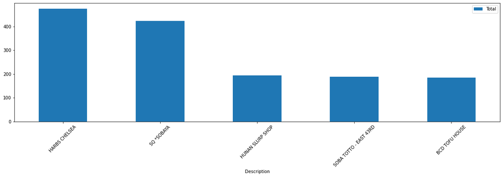

```python
dining_totals = dining_totals.sort_values(by=["Total"], ascending=False)
ax = dining_totals.nlargest(5, "Total").plot.bar(rot=45, figsize=(20,5))
```

In 2019, the restaurants I spent the most money at were:

1. [HARBS Chelsea](https://goo.gl/maps/WPYSRpfUoRjhDXyp8)
2. [Sobaya](https://goo.gl/maps/jWSrS8mYSesGTGT2A)
3. [Hunan Slurp](https://goo.gl/maps/wnxe8uYSHYjfAnxn7)
4. [Soba Totto](https://goo.gl/maps/cZpaNf7VM9aZzs5M8)
5. [BCD Tofu House](https://goo.gl/maps/VibDhrNXM1PMSXBE6)

I have many fond memories of spending long afternoons and late nights at these restaurants eating, drinking, and celebrating with loved onces. Seeing this list reminds me that, while I could save money by not eating out, I'd rather splurge on nice meals for family and friends because it makes me a happier person.

In conclusion, I hope this tutorial can help you analyze your own personal finances, and perhaps learn something new about yourself!